# Lactobacillus 16s Analysis

Sam McMillan

2023-09-14

General setup

```r
knitr::opts_chunk$set(echo = TRUE)
knitr::opts_knit$set(root.dir = 'Q:/My Drive/Lab Work/Data/Lacto 16S')

library(tidyverse)
library(dada2)
library(phyloseq)
```

The data includes 16S amplicon reads from mice CDI model 3 types of sample tissues (feces, ileum, and cecum), 4 different times of challenge (day 0, 7, 14, 21), and 4 types of treatments(Cefoperazone only, C. difficile only, L. acidophilus + C. difficile, and L. gasseri + C. difficile). Total 192 samples (Forward and Reverse for each: 384 reads)

We’re going to QC reads using DADA2, then use Phyloseq to categorize everything #######DADA2########## files are found on Google Drive, I’m using google drive sync to access the files Filenames are [cage]-[mouse]-[challenge day]-[treatment]-[sample tissue]_[SeqInfo]*L001*[(R1=Forward,R2=Reverse)]_001.fastq.gz

treatments: Cefoperazone only=No, C. difficile only=Cd, L. acidophilus + C. difficile=La, and L. gasseri + C. difficile=Lg sample tissue: feces=fe, ileum=il, and cecum=ce

SeqInfo isn’t important

```r
#files are found on Google Drive, I'm using google drive sync to access the files
path<-"Q:/.shortcut-targets-by-id/0BwNUpRTHaLxFaVZDZURmVTZsSXc/Theriot Lab/2. Data Dump/Rajani/Computer Files/Lacto_16S/Data/reads"

#split forward and reverse, make sure they're in the right order
fnFs <- sort(list.files(path, pattern="_R1_001.fastq.gz", full.names = TRUE))
fnRs <- sort(list.files(path, pattern="_R2_001.fastq.gz", full.names = TRUE))

#cut everything after the "_" to get just the names
sample.names <- sapply(strsplit(basename(fnFs), "_"), `[`, 1)

#quick check
fnFs[[1]]; fnRs[[1]]
```

```
## [1] "Q:/.shortcut-targets-by-id/0BwNUpRTHaLxFaVZDZURmVTZsSXc/Theriot Lab/2. Data Dump/Rajani/Computer Files/Lacto_16S/Data/reads/237-1-d0-No-ce_S229_L001_R1_001.fastq.gz"
```

```
## [1] "Q:/.shortcut-targets-by-id/0BwNUpRTHaLxFaVZDZURmVTZsSXc/Theriot Lab/2. Data Dump/Rajani/Computer Files/Lacto_16S/Data/reads/237-1-d0-No-ce_S229_L001_R2_001.fastq.gz"
```

```r
sample(sample.names,10)
```

```
##  [1] "248-2-d14-Lg-ce" "249-1-d21-No-il" "239-1-d0-La-ce"  "237-3-d0-No-il"
##  [5] "251-2-d21-La-ce" "245-3-d14-No-fe" "244-2-d7-Lg-fe"  "244-4-d7-Lg-il"
##  [9] "249-2-d21-No-fe" "240-3-d0-Lg-ce"
```

Lets check the read quality. This takes a bit too long to do all the samples, so lets random sample 5.

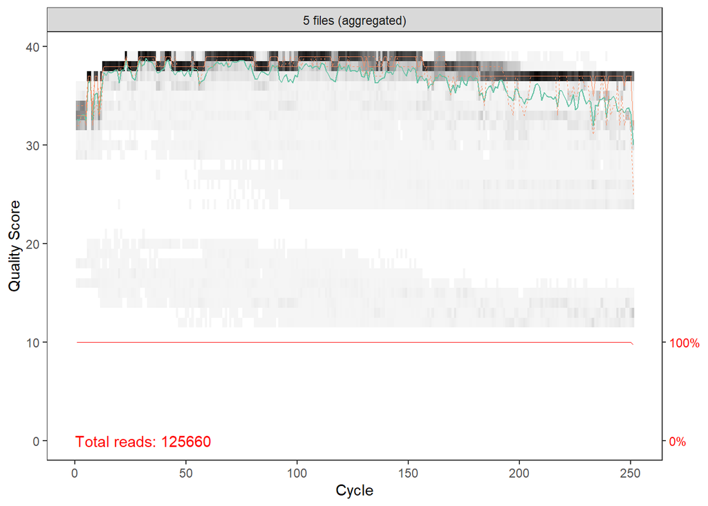

```r
set.seed(25519)
plotQualityProfile(sample(fnFs,5),aggregate=TRUE)
```

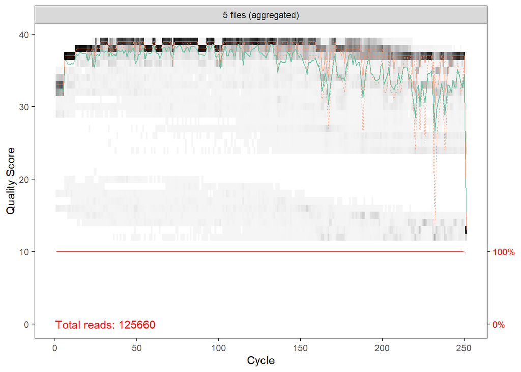

```r
set.seed(25519)
plotQualityProfile(sample(fnRs,5),aggregate=TRUE)
```

Based on quality profiles, I’ll set the following cutoffs Forward reads: 240 (Rajani did 250, but dada tutorial recommends cutting at least the last 10) Reverse Reads 150 So we will truncate at those numbers. Lets filter.

dada tutorial recommends standard filtering parameters: maxN=0 (DADA2 requires no Ns), truncQ=2, rm.phix=TRUE and maxEE=2. The maxEE parameter sets the maximum number of “expected errors” allowed in a read, which is a better filter than simply averaging quality scores. rm.phix removes reads that match the phiX genome.phiX is a common phage contaminant

```r
path2<-'Q:/My Drive/Lab Work/Data/Lacto 16S'
filtFs <- file.path(path2, "Analysis/filtered reads", paste0(sample.names, "_F_filt.fastq.gz"))
filtRs <- file.path(path2, "Analysis/filtered reads", paste0(sample.names, "_R_filt.fastq.gz"))
names(filtFs) <- sample.names
names(filtRs) <- sample.names

out <- filterAndTrim(fnFs, filtFs, fnRs, filtRs, truncLen=c(240,150),
              maxN=0, maxEE=c(2,2),truncQ=2, rm.phix=TRUE,
              compress=TRUE, multithread=FALSE) # On Mac set multithread=TRUE

head(out)
```

```
##                                          reads.in reads.out
## 237-1-d0-No-ce_S229_L001_R1_001.fastq.gz    35604     34388
## 237-1-d0-No-fe_S97_L001_R1_001.fastq.gz     23721     23005
## 237-1-d0-No-il_S163_L001_R1_001.fastq.gz     3780      3696
## 237-2-d0-No-ce_S230_L001_R1_001.fastq.gz    36240     34779
## 237-2-d0-No-fe_S98_L001_R1_001.fastq.gz     26590     25921
## 237-2-d0-No-il_S164_L001_R1_001.fastq.gz     7498      7211
```

Next, lets check the error rates

```r
errF <- learnErrors(filtFs, multithread=TRUE)
```

```
## 102481440 total bases in 427006 reads from 20 samples will be used for learning the error rates.
```

```r
errR <- learnErrors(filtRs, multithread=TRUE)
```

```
## 104143350 total bases in 694289 reads from 35 samples will be used for learning the error rates.
```

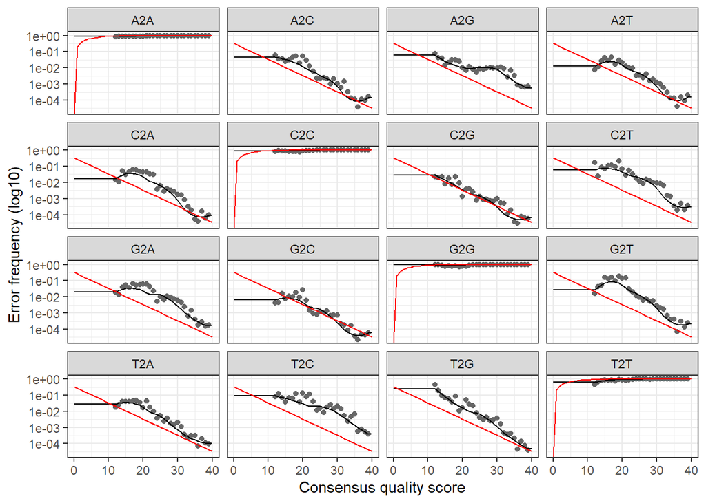

```r
plotErrors(errF, nominalQ=TRUE)
```

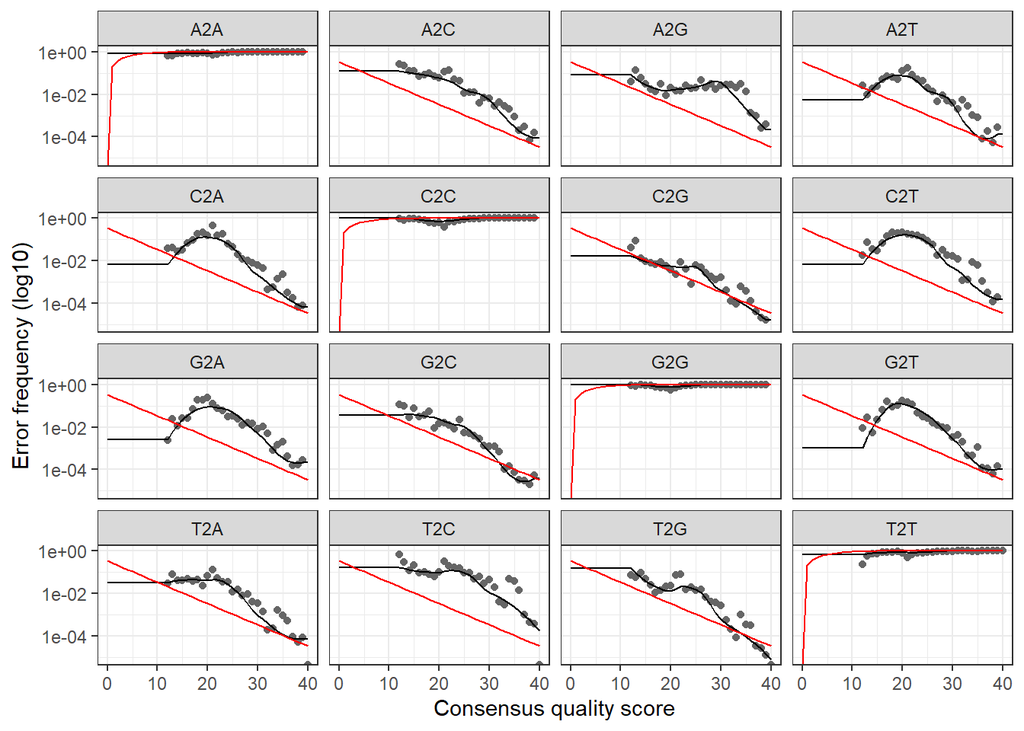

```r
plotErrors(errR, nominalQ=TRUE)
```

The red line above is the “error rates expected under the nominal defintion of the Q-score”. Here we are checking that the black line is decreasing as quality increases. We also want to make sure that black line properly reflects the points.

This looks good for the forward and reverse, we’re OK with this error rate calculation.

Next we’ll move onto the sample inference. This is the dada2 like big deal that corrects errors.

```r
dadaFs <- dada(filtFs, err=errF, multithread=TRUE)
```

```
## Sample 1 - 34388 reads in 3892 unique sequences.
## Sample 2 - 23005 reads in 2784 unique sequences.
## Sample 3 - 3696 reads in 725 unique sequences.
## Sample 4 - 34779 reads in 4524 unique sequences.
## Sample 5 - 25921 reads in 1965 unique sequences.
## Sample 6 - 7211 reads in 1507 unique sequences.
## Sample 7 - 16561 reads in 2244 unique sequences.
## Sample 8 - 35373 reads in 2902 unique sequences.
## Sample 9 - 4320 reads in 869 unique sequences.
## Sample 10 - 26730 reads in 3299 unique sequences.
## Sample 11 - 36380 reads in 2848 unique sequences.
## Sample 12 - 4700 reads in 866 unique sequences.
## Sample 13 - 25499 reads in 4278 unique sequences.
## Sample 14 - 30202 reads in 2089 unique sequences.
## Sample 15 - 4555 reads in 758 unique sequences.
## Sample 16 - 34456 reads in 5643 unique sequences.
## Sample 17 - 33554 reads in 2500 unique sequences.
## Sample 18 - 1884 reads in 316 unique sequences.
## Sample 19 - 17348 reads in 3036 unique sequences.
## Sample 20 - 26444 reads in 1822 unique sequences.
## Sample 21 - 2321 reads in 512 unique sequences.
## Sample 22 - 30884 reads in 5653 unique sequences.
## Sample 23 - 34457 reads in 2902 unique sequences.
## Sample 24 - 302 reads in 84 unique sequences.
## Sample 25 - 10450 reads in 1438 unique sequences.
## Sample 26 - 32823 reads in 2527 unique sequences.
## Sample 27 - 4250 reads in 735 unique sequences.
## Sample 28 - 16991 reads in 2377 unique sequences.
## Sample 29 - 35497 reads in 2648 unique sequences.
## Sample 30 - 1296 reads in 318 unique sequences.
## Sample 31 - 8274 reads in 1511 unique sequences.
## Sample 32 - 38065 reads in 2731 unique sequences.
## Sample 33 - 7352 reads in 1009 unique sequences.
## Sample 34 - 13972 reads in 2493 unique sequences.
## Sample 35 - 30349 reads in 2177 unique sequences.
## Sample 36 - 2165 reads in 482 unique sequences.
## Sample 37 - 23297 reads in 2749 unique sequences.
## Sample 38 - 23116 reads in 2930 unique sequences.
## Sample 39 - 4091 reads in 702 unique sequences.
## Sample 40 - 10400 reads in 1389 unique sequences.
```

[output cut: 137 more lines]

```
## Sample 178 - 23069 reads in 4867 unique sequences.
## Sample 179 - 24894 reads in 6815 unique sequences.
## Sample 180 - 20691 reads in 4130 unique sequences.
## Sample 181 - 23031 reads in 5289 unique sequences.
## Sample 182 - 26533 reads in 6303 unique sequences.
## Sample 183 - 25314 reads in 4423 unique sequences.
## Sample 184 - 12590 reads in 3070 unique sequences.
## Sample 185 - 23026 reads in 6619 unique sequences.
## Sample 186 - 10135 reads in 2057 unique sequences.
## Sample 187 - 14656 reads in 3255 unique sequences.
## Sample 188 - 23716 reads in 5264 unique sequences.
## Sample 189 - 777 reads in 262 unique sequences.
## Sample 190 - 497 reads in 212 unique sequences.
## Sample 191 - 27048 reads in 7634 unique sequences.
## Sample 192 - 2499 reads in 479 unique sequences.
```

```r
dadaRs <- dada(filtRs, err=errR, multithread=TRUE)
```

```
## Sample 1 - 34388 reads in 2375 unique sequences.
## Sample 2 - 23005 reads in 1877 unique sequences.
## Sample 3 - 3696 reads in 471 unique sequences.
## Sample 4 - 34779 reads in 2724 unique sequences.
## Sample 5 - 25921 reads in 1171 unique sequences.
## Sample 6 - 7211 reads in 1051 unique sequences.
## Sample 7 - 16561 reads in 1400 unique sequences.
## Sample 8 - 35373 reads in 1672 unique sequences.
## Sample 9 - 4320 reads in 573 unique sequences.
## Sample 10 - 26730 reads in 2060 unique sequences.
## Sample 11 - 36380 reads in 1789 unique sequences.
## Sample 12 - 4700 reads in 605 unique sequences.
## Sample 13 - 25499 reads in 2924 unique sequences.
## Sample 14 - 30202 reads in 1311 unique sequences.
## Sample 15 - 4555 reads in 565 unique sequences.
## Sample 16 - 34456 reads in 3813 unique sequences.
## Sample 17 - 33554 reads in 1709 unique sequences.
## Sample 18 - 1884 reads in 223 unique sequences.
## Sample 19 - 17348 reads in 2110 unique sequences.
## Sample 20 - 26444 reads in 982 unique sequences.
## Sample 21 - 2321 reads in 441 unique sequences.
## Sample 22 - 30884 reads in 3683 unique sequences.
## Sample 23 - 34457 reads in 1800 unique sequences.
## Sample 24 - 302 reads in 69 unique sequences.
## Sample 25 - 10450 reads in 984 unique sequences.
## Sample 26 - 32823 reads in 1358 unique sequences.
## Sample 27 - 4250 reads in 593 unique sequences.
## Sample 28 - 16991 reads in 1515 unique sequences.
## Sample 29 - 35497 reads in 1502 unique sequences.
## Sample 30 - 1296 reads in 259 unique sequences.
## Sample 31 - 8274 reads in 1082 unique sequences.
## Sample 32 - 38065 reads in 1546 unique sequences.
## Sample 33 - 7352 reads in 827 unique sequences.
## Sample 34 - 13972 reads in 1577 unique sequences.
## Sample 35 - 30349 reads in 1224 unique sequences.
## Sample 36 - 2165 reads in 425 unique sequences.
## Sample 37 - 23297 reads in 2078 unique sequences.
## Sample 38 - 23116 reads in 2132 unique sequences.
## Sample 39 - 4091 reads in 489 unique sequences.
## Sample 40 - 10400 reads in 1081 unique sequences.
```

[output cut: 137 more lines]

```
## Sample 178 - 23069 reads in 3596 unique sequences.
## Sample 179 - 24894 reads in 4706 unique sequences.
## Sample 180 - 20691 reads in 2942 unique sequences.
## Sample 181 - 23031 reads in 3882 unique sequences.
## Sample 182 - 26533 reads in 4610 unique sequences.
## Sample 183 - 25314 reads in 2840 unique sequences.
## Sample 184 - 12590 reads in 2304 unique sequences.
## Sample 185 - 23026 reads in 4708 unique sequences.
## Sample 186 - 10135 reads in 1117 unique sequences.
## Sample 187 - 14656 reads in 2260 unique sequences.
## Sample 188 - 23716 reads in 3872 unique sequences.
## Sample 189 - 777 reads in 219 unique sequences.
## Sample 190 - 497 reads in 185 unique sequences.
## Sample 191 - 27048 reads in 5547 unique sequences.
## Sample 192 - 2499 reads in 366 unique sequences.
```

```r
#take a peek
dadaFs[[1]]
```

```
## dada-class: object describing DADA2 denoising results
## 15 sequence variants were inferred from 3892 input unique sequences.
## Key parameters: OMEGA_A = 1e-40, OMEGA_C = 1e-40, BAND_SIZE = 16
```

```r
head(getSequences(dadaFs[[1]]))
```

```
## [1] "TACGTAGGTGGCAAGCGTTGTCCGGATTTATTGGGCGTAAAGCGAGCGCAGGCGGTTTCT…"
## [2] "TACGTAGGGGGCAAGCGTTATCCGGATTTACTGGGTGTAAAGGGAGCGTAGACGGTAATG…"
## [3] "TACGTAGGGTGCGAGCGTTAATCGGAATTACTGGGCGTAAAGGGTGCGCAGGCGGTTGAG…"
## [4] "TACGTAGGTGGCAAGCGTTATCCGGAATTATTGGGCGTAAAGAGCGCGCAGGTGGTTAAT…"
## [5] "TACGTAGGGGGCGAGCGTTATCCGGATTCATTGGGCGTAAAGCGCGCGTAGGCGGCCGCC…"
## [6] "TACGTAGGTGGCAAGCGTTATCCGGAATTATTGGGCGTAAAGCGCGCGTAGGCGGTTTCT…"
```

Next we need to merge the paired ends

```r
mergers <- mergePairs(dadaFs, filtFs, dadaRs, filtRs, verbose=TRUE)
```

```
## 34238 paired-reads (in 13 unique pairings) successfully merged out of 34300 (in 39 pairings) input.
```

```
## 22693 paired-reads (in 73 unique pairings) successfully merged out of 22837 (in 144 pairings) input.
```

```
## 3666 paired-reads (in 11 unique pairings) successfully merged out of 3668 (in 13 pairings) input.
```

```
## 34674 paired-reads (in 18 unique pairings) successfully merged out of 34708 (in 39 pairings) input.
```

```
## 25877 paired-reads (in 4 unique pairings) successfully merged out of 25885 (in 7 pairings) input.
```

```
## 7103 paired-reads (in 9 unique pairings) successfully merged out of 7149 (in 25 pairings) input.
```

```
## 16485 paired-reads (in 13 unique pairings) successfully merged out of 16507 (in 24 pairings) input.
```

```
## 35284 paired-reads (in 9 unique pairings) successfully merged out of 35303 (in 18 pairings) input.
```

```
## 4256 paired-reads (in 9 unique pairings) successfully merged out of 4268 (in 15 pairings) input.
```

```
## 26631 paired-reads (in 30 unique pairings) successfully merged out of 26692 (in 49 pairings) input.
```

```
## 36304 paired-reads (in 5 unique pairings) successfully merged out of 36321 (in 11 pairings) input.
```

```
## 4646 paired-reads (in 8 unique pairings) successfully merged out of 4665 (in 17 pairings) input.
```

```
## 25248 paired-reads (in 34 unique pairings) successfully merged out of 25377 (in 84 pairings) input.
```

```
## 30135 paired-reads (in 6 unique pairings) successfully merged out of 30149 (in 13 pairings) input.
```

```
## 4506 paired-reads (in 15 unique pairings) successfully merged out of 4523 (in 28 pairings) input.
```

```
## 34166 paired-reads (in 51 unique pairings) successfully merged out of 34319 (in 116 pairings) input.
```

```
## 33509 paired-reads (in 10 unique pairings) successfully merged out of 33521 (in 16 pairings) input.
```

```
## 1860 paired-reads (in 6 unique pairings) successfully merged out of 1863 (in 8 pairings) input.
```

```
## 17230 paired-reads (in 45 unique pairings) successfully merged out of 17293 (in 88 pairings) input.
```

```
## 26410 paired-reads (in 5 unique pairings) successfully merged out of 26419 (in 9 pairings) input.
```

```
## 2242 paired-reads (in 35 unique pairings) successfully merged out of 2277 (in 62 pairings) input.
```

```
## 30526 paired-reads (in 60 unique pairings) successfully merged out of 30694 (in 138 pairings) input.
```

```
## 34389 paired-reads (in 6 unique pairings) successfully merged out of 34405 (in 11 pairings) input.
```

```
## 278 paired-reads (in 3 unique pairings) successfully merged out of 281 (in 4 pairings) input.
```

```
## 10390 paired-reads (in 16 unique pairings) successfully merged out of 10413 (in 35 pairings) input.
```

```
## 32760 paired-reads (in 5 unique pairings) successfully merged out of 32774 (in 12 pairings) input.
```

```
## 4174 paired-reads (in 13 unique pairings) successfully merged out of 4194 (in 23 pairings) input.
```

```
## 16911 paired-reads (in 22 unique pairings) successfully merged out of 16950 (in 45 pairings) input.
```

```
## 35436 paired-reads (in 6 unique pairings) successfully merged out of 35436 (in 6 pairings) input.
```

```
## 1235 paired-reads (in 11 unique pairings) successfully merged out of 1263 (in 23 pairings) input.
```

```
## 8192 paired-reads (in 17 unique pairings) successfully merged out of 8242 (in 48 pairings) input.
```

```
## 38007 paired-reads (in 6 unique pairings) successfully merged out of 38015 (in 10 pairings) input.
```

```
## 7316 paired-reads (in 7 unique pairings) successfully merged out of 7324 (in 13 pairings) input.
```

```
## 13872 paired-reads (in 24 unique pairings) successfully merged out of 13907 (in 47 pairings) input.
```

```
## 30280 paired-reads (in 8 unique pairings) successfully merged out of 30302 (in 17 pairings) input.
```

```
## 2102 paired-reads (in 12 unique pairings) successfully merged out of 2124 (in 20 pairings) input.
```

```
## 23164 paired-reads (in 21 unique pairings) successfully merged out of 23226 (in 63 pairings) input.
```

```
## 22982 paired-reads (in 33 unique pairings) successfully merged out of 23053 (in 71 pairings) input.
```

```
## 4034 paired-reads (in 8 unique pairings) successfully merged out of 4046 (in 17 pairings) input.
```

```
## 10336 paired-reads (in 13 unique pairings) successfully merged out of 10352 (in 27 pairings) input.
```

```
## 19852 paired-reads (in 8 unique pairings) successfully merged out of 19860 (in 12 pairings) input.
```

```
## 2549 paired-reads (in 4 unique pairings) successfully merged out of 2561 (in 11 pairings) input.
```

```
## 8740 paired-reads (in 25 unique pairings) successfully merged out of 8756 (in 40 pairings) input.
```

```
## 37518 paired-reads (in 3 unique pairings) successfully merged out of 37532 (in 6 pairings) input.
```

```
## 3342 paired-reads (in 11 unique pairings) successfully merged out of 3372 (in 20 pairings) input.
```

```
## 4548 paired-reads (in 14 unique pairings) successfully merged out of 4562 (in 28 pairings) input.
```

```
## 33396 paired-reads (in 9 unique pairings) successfully merged out of 33426 (in 17 pairings) input.
```

```
## 744 paired-reads (in 3 unique pairings) successfully merged out of 747 (in 4 pairings) input.
```

```
## 34469 paired-reads (in 110 unique pairings) successfully merged out of 34744 (in 254 pairings) input.
```

```
## 26724 paired-reads (in 90 unique pairings) successfully merged out of 27064 (in 242 pairings) input.
```

```
## 7114 paired-reads (in 56 unique pairings) successfully merged out of 7174 (in 85 pairings) input.
```

```
## 30819 paired-reads (in 119 unique pairings) successfully merged out of 31021 (in 239 pairings) input.
```

```
## 15902 paired-reads (in 83 unique pairings) successfully merged out of 16194 (in 206 pairings) input.
```

```
## 4004 paired-reads (in 56 unique pairings) successfully merged out of 4052 (in 67 pairings) input.
```

```
## 32253 paired-reads (in 106 unique pairings) successfully merged out of 32525 (in 246 pairings) input.
```

```
## 12120 paired-reads (in 72 unique pairings) successfully merged out of 12254 (in 128 pairings) input.
```

```
## 19722 paired-reads (in 82 unique pairings) successfully merged out of 19774 (in 121 pairings) input.
```

```
## 34094 paired-reads (in 133 unique pairings) successfully merged out of 34565 (in 367 pairings) input.
```

```
## 28162 paired-reads (in 100 unique pairings) successfully merged out of 28549 (in 288 pairings) input.
```

```
## 3586 paired-reads (in 35 unique pairings) successfully merged out of 3621 (in 58 pairings) input.
```

```
## 25853 paired-reads (in 68 unique pairings) successfully merged out of 26141 (in 159 pairings) input.
```

```
## 32001 paired-reads (in 86 unique pairings) successfully merged out of 32391 (in 251 pairings) input.
```

```
## 1103 paired-reads (in 19 unique pairings) successfully merged out of 1119 (in 31 pairings) input.
```

```
## 29911 paired-reads (in 98 unique pairings) successfully merged out of 30203 (in 224 pairings) input.
```

```
## 30016 paired-reads (in 145 unique pairings) successfully merged out of 30614 (in 416 pairings) input.
```

```
## 1729 paired-reads (in 32 unique pairings) successfully merged out of 1749 (in 46 pairings) input.
```

```
## 19140 paired-reads (in 72 unique pairings) successfully merged out of 19387 (in 167 pairings) input.
```

```
## 22734 paired-reads (in 98 unique pairings) successfully merged out of 23324 (in 330 pairings) input.
```

```
## 1386 paired-reads (in 21 unique pairings) successfully merged out of 1405 (in 34 pairings) input.
```

```
## 24638 paired-reads (in 66 unique pairings) successfully merged out of 24843 (in 157 pairings) input.
```

```
## 26281 paired-reads (in 95 unique pairings) successfully merged out of 26588 (in 249 pairings) input.
```

```
## 1119 paired-reads (in 22 unique pairings) successfully merged out of 1138 (in 35 pairings) input.
```

```
## 27141 paired-reads (in 118 unique pairings) successfully merged out of 27512 (in 350 pairings) input.
```

```
## 27603 paired-reads (in 107 unique pairings) successfully merged out of 28041 (in 310 pairings) input.
```

```
## 2394 paired-reads (in 40 unique pairings) successfully merged out of 2422 (in 56 pairings) input.
```

```
## 21936 paired-reads (in 98 unique pairings) successfully merged out of 22116 (in 180 pairings) input.
```

```
## 17812 paired-reads (in 76 unique pairings) successfully merged out of 18115 (in 226 pairings) input.
```

```
## 766 paired-reads (in 13 unique pairings) successfully merged out of 774 (in 19 pairings) input.
```

```
## 14875 paired-reads (in 112 unique pairings) successfully merged out of 15106 (in 211 pairings) input.
```

```
## 17133 paired-reads (in 78 unique pairings) successfully merged out of 17431 (in 213 pairings) input.
```

```
## 4097 paired-reads (in 36 unique pairings) successfully merged out of 4124 (in 57 pairings) input.
```

```
## 29168 paired-reads (in 108 unique pairings) successfully merged out of 29542 (in 298 pairings) input.
```

```
## 31783 paired-reads (in 132 unique pairings) successfully merged out of 32462 (in 360 pairings) input.
```

```
## 3130 paired-reads (in 29 unique pairings) successfully merged out of 3200 (in 55 pairings) input.
```

```
## 19289 paired-reads (in 123 unique pairings) successfully merged out of 19822 (in 370 pairings) input.
```

```
## 19399 paired-reads (in 136 unique pairings) successfully merged out of 20319 (in 478 pairings) input.
```

```
## 6133 paired-reads (in 68 unique pairings) successfully merged out of 6222 (in 88 pairings) input.
```

```
## 17886 paired-reads (in 108 unique pairings) successfully merged out of 18168 (in 256 pairings) input.
```

```
## 20664 paired-reads (in 121 unique pairings) successfully merged out of 21053 (in 303 pairings) input.
```

```
## 11511 paired-reads (in 73 unique pairings) successfully merged out of 11604 (in 129 pairings) input.
```

```
## 14567 paired-reads (in 102 unique pairings) successfully merged out of 14719 (in 184 pairings) input.
```

```
## 22038 paired-reads (in 114 unique pairings) successfully merged out of 22605 (in 343 pairings) input.
```

```
## 7465 paired-reads (in 41 unique pairings) successfully merged out of 7509 (in 53 pairings) input.
```

```
## 28952 paired-reads (in 119 unique pairings) successfully merged out of 29400 (in 322 pairings) input.
```

```
## 25666 paired-reads (in 101 unique pairings) successfully merged out of 26010 (in 267 pairings) input.
```

```
## 21019 paired-reads (in 100 unique pairings) successfully merged out of 21188 (in 162 pairings) input.
```

```
## 24298 paired-reads (in 119 unique pairings) successfully merged out of 24657 (in 313 pairings) input.
```

```
## 30891 paired-reads (in 166 unique pairings) successfully merged out of 31722 (in 535 pairings) input.
```

```
## 2933 paired-reads (in 61 unique pairings) successfully merged out of 2961 (in 77 pairings) input.
```

```
## 14166 paired-reads (in 100 unique pairings) successfully merged out of 14247 (in 155 pairings) input.
```

```
## 26876 paired-reads (in 154 unique pairings) successfully merged out of 27767 (in 528 pairings) input.
```

```
## 3165 paired-reads (in 21 unique pairings) successfully merged out of 3191 (in 31 pairings) input.
```

```
## 15590 paired-reads (in 97 unique pairings) successfully merged out of 15717 (in 182 pairings) input.
```

```
## 28010 paired-reads (in 142 unique pairings) successfully merged out of 28458 (in 337 pairings) input.
```

```
## 14852 paired-reads (in 94 unique pairings) successfully merged out of 14947 (in 141 pairings) input.
```

```
## 17600 paired-reads (in 97 unique pairings) successfully merged out of 17731 (in 184 pairings) input.
```

```
## 25385 paired-reads (in 177 unique pairings) successfully merged out of 26668 (in 631 pairings) input.
```

```
## 2921 paired-reads (in 11 unique pairings) successfully merged out of 2934 (in 17 pairings) input.
```

```
## 27495 paired-reads (in 126 unique pairings) successfully merged out of 27758 (in 280 pairings) input.
```

```
## 27082 paired-reads (in 138 unique pairings) successfully merged out of 27405 (in 341 pairings) input.
```

```
## 2409 paired-reads (in 40 unique pairings) successfully merged out of 2504 (in 60 pairings) input.
```

```
## 22887 paired-reads (in 116 unique pairings) successfully merged out of 23045 (in 224 pairings) input.
```

```
## 22997 paired-reads (in 153 unique pairings) successfully merged out of 23463 (in 423 pairings) input.
```

```
## 2996 paired-reads (in 15 unique pairings) successfully merged out of 3005 (in 20 pairings) input.
```

```
## 14951 paired-reads (in 91 unique pairings) successfully merged out of 15066 (in 147 pairings) input.
```

```
## 31343 paired-reads (in 183 unique pairings) successfully merged out of 32216 (in 600 pairings) input.
```

```
## 18348 paired-reads (in 91 unique pairings) successfully merged out of 18487 (in 145 pairings) input.
```

```
## 22100 paired-reads (in 108 unique pairings) successfully merged out of 22326 (in 204 pairings) input.
```

```
## 33545 paired-reads (in 196 unique pairings) successfully merged out of 34782 (in 738 pairings) input.
```

```
## 709 paired-reads (in 10 unique pairings) successfully merged out of 718 (in 17 pairings) input.
```

```
## 21994 paired-reads (in 101 unique pairings) successfully merged out of 22225 (in 221 pairings) input.
```

```
## 29331 paired-reads (in 138 unique pairings) successfully merged out of 29983 (in 424 pairings) input.
```

```
## 5563 paired-reads (in 70 unique pairings) successfully merged out of 5635 (in 115 pairings) input.
```

```
## 30113 paired-reads (in 123 unique pairings) successfully merged out of 30520 (in 330 pairings) input.
```

```
## 28671 paired-reads (in 140 unique pairings) successfully merged out of 29624 (in 494 pairings) input.
```

```
## 7585 paired-reads (in 49 unique pairings) successfully merged out of 7677 (in 82 pairings) input.
```

```
## 18269 paired-reads (in 107 unique pairings) successfully merged out of 18589 (in 251 pairings) input.
```

```
## 28360 paired-reads (in 136 unique pairings) successfully merged out of 28841 (in 344 pairings) input.
```

```
## 6140 paired-reads (in 31 unique pairings) successfully merged out of 6168 (in 49 pairings) input.
```

```
## 29436 paired-reads (in 118 unique pairings) successfully merged out of 29955 (in 326 pairings) input.
```

```
## 31898 paired-reads (in 133 unique pairings) successfully merged out of 32349 (in 390 pairings) input.
```

```
## 3641 paired-reads (in 23 unique pairings) successfully merged out of 3687 (in 37 pairings) input.
```

```
## 27806 paired-reads (in 156 unique pairings) successfully merged out of 28045 (in 271 pairings) input.
```

```
## 34699 paired-reads (in 167 unique pairings) successfully merged out of 35121 (in 320 pairings) input.
```

```
## 3028 paired-reads (in 14 unique pairings) successfully merged out of 3056 (in 24 pairings) input.
```

```
## 27007 paired-reads (in 152 unique pairings) successfully merged out of 27313 (in 273 pairings) input.
```

```
## 30472 paired-reads (in 206 unique pairings) successfully merged out of 31139 (in 443 pairings) input.
```

```
## 6799 paired-reads (in 59 unique pairings) successfully merged out of 6855 (in 81 pairings) input.
```

```
## 20914 paired-reads (in 133 unique pairings) successfully merged out of 21159 (in 231 pairings) input.
```

```
## 33211 paired-reads (in 197 unique pairings) successfully merged out of 33811 (in 472 pairings) input.
```

```
## 1158 paired-reads (in 45 unique pairings) successfully merged out of 1222 (in 74 pairings) input.
```

```
## 21082 paired-reads (in 137 unique pairings) successfully merged out of 21252 (in 219 pairings) input.
```

```
## 29025 paired-reads (in 208 unique pairings) successfully merged out of 29959 (in 549 pairings) input.
```

```
## 3679 paired-reads (in 25 unique pairings) successfully merged out of 3708 (in 39 pairings) input.
```

```
## 30964 paired-reads (in 120 unique pairings) successfully merged out of 31304 (in 318 pairings) input.
```

```
## 21079 paired-reads (in 147 unique pairings) successfully merged out of 21838 (in 495 pairings) input.
```

```
## 23019 paired-reads (in 109 unique pairings) successfully merged out of 23132 (in 185 pairings) input.
```

```
## 22482 paired-reads (in 116 unique pairings) successfully merged out of 22621 (in 216 pairings) input.
```

```
## 20825 paired-reads (in 128 unique pairings) successfully merged out of 21243 (in 324 pairings) input.
```

```
## 23438 paired-reads (in 99 unique pairings) successfully merged out of 23542 (in 149 pairings) input.
```

```
## 17812 paired-reads (in 106 unique pairings) successfully merged out of 17895 (in 161 pairings) input.
```

```
## 25906 paired-reads (in 161 unique pairings) successfully merged out of 26830 (in 551 pairings) input.
```

```
## 8644 paired-reads (in 35 unique pairings) successfully merged out of 8702 (in 66 pairings) input.
```

```
## 18753 paired-reads (in 108 unique pairings) successfully merged out of 18932 (in 215 pairings) input.
```

```
## 21776 paired-reads (in 130 unique pairings) successfully merged out of 22505 (in 455 pairings) input.
```

```
## 3755 paired-reads (in 33 unique pairings) successfully merged out of 3777 (in 45 pairings) input.
```

```
## 19740 paired-reads (in 114 unique pairings) successfully merged out of 19938 (in 218 pairings) input.
```

```
## 27893 paired-reads (in 200 unique pairings) successfully merged out of 28708 (in 596 pairings) input.
```

```
## 1847 paired-reads (in 53 unique pairings) successfully merged out of 1902 (in 77 pairings) input.
```

```
## 25255 paired-reads (in 127 unique pairings) successfully merged out of 25507 (in 257 pairings) input.
```

```
## 24886 paired-reads (in 161 unique pairings) successfully merged out of 26035 (in 686 pairings) input.
```

```
## 4311 paired-reads (in 76 unique pairings) successfully merged out of 4362 (in 109 pairings) input.
```

```
## 23418 paired-reads (in 121 unique pairings) successfully merged out of 23710 (in 282 pairings) input.
```

```
## 18256 paired-reads (in 129 unique pairings) successfully merged out of 18799 (in 380 pairings) input.
```

```
## 19624 paired-reads (in 73 unique pairings) successfully merged out of 19724 (in 117 pairings) input.
```

```
## 24280 paired-reads (in 118 unique pairings) successfully merged out of 24559 (in 192 pairings) input.
```

```
## 22105 paired-reads (in 160 unique pairings) successfully merged out of 22974 (in 537 pairings) input.
```

```
## 10732 paired-reads (in 92 unique pairings) successfully merged out of 10779 (in 117 pairings) input.
```

```
## 27075 paired-reads (in 104 unique pairings) successfully merged out of 27217 (in 190 pairings) input.
```

```
## 22841 paired-reads (in 163 unique pairings) successfully merged out of 23817 (in 601 pairings) input.
```

```
## 2870 paired-reads (in 63 unique pairings) successfully merged out of 2895 (in 76 pairings) input.
```

```
## 23132 paired-reads (in 119 unique pairings) successfully merged out of 23239 (in 188 pairings) input.
```

```
## 29778 paired-reads (in 186 unique pairings) successfully merged out of 30647 (in 595 pairings) input.
```

```
## 7987 paired-reads (in 83 unique pairings) successfully merged out of 8070 (in 109 pairings) input.
```

```
## 15841 paired-reads (in 105 unique pairings) successfully merged out of 15969 (in 183 pairings) input.
```

```
## 31258 paired-reads (in 173 unique pairings) successfully merged out of 32152 (in 555 pairings) input.
```

```
## 457 paired-reads (in 9 unique pairings) successfully merged out of 462 (in 12 pairings) input.
```

```
## 22825 paired-reads (in 102 unique pairings) successfully merged out of 22959 (in 180 pairings) input.
```

```
## 23247 paired-reads (in 165 unique pairings) successfully merged out of 24309 (in 584 pairings) input.
```

```
## 20522 paired-reads (in 97 unique pairings) successfully merged out of 20644 (in 143 pairings) input.
```

```
## 22559 paired-reads (in 141 unique pairings) successfully merged out of 22837 (in 325 pairings) input.
```

```
## 25446 paired-reads (in 132 unique pairings) successfully merged out of 26100 (in 399 pairings) input.
```

```
## 25100 paired-reads (in 71 unique pairings) successfully merged out of 25231 (in 130 pairings) input.
```

```
## 12363 paired-reads (in 123 unique pairings) successfully merged out of 12510 (in 217 pairings) input.
```

```
## 22030 paired-reads (in 152 unique pairings) successfully merged out of 22615 (in 447 pairings) input.
```

```
## 10093 paired-reads (in 35 unique pairings) successfully merged out of 10112 (in 50 pairings) input.
```

```
## 14348 paired-reads (in 108 unique pairings) successfully merged out of 14513 (in 186 pairings) input.
```

```
## 22902 paired-reads (in 131 unique pairings) successfully merged out of 23348 (in 337 pairings) input.
```

```
## 694 paired-reads (in 26 unique pairings) successfully merged out of 744 (in 44 pairings) input.
```

```
## 412 paired-reads (in 31 unique pairings) successfully merged out of 435 (in 43 pairings) input.
```

```
## 25526 paired-reads (in 147 unique pairings) successfully merged out of 26511 (in 535 pairings) input.
```

```
## 2463 paired-reads (in 18 unique pairings) successfully merged out of 2467 (in 21 pairings) input.
```

```r
head(mergers[[1]])
```

```
##                                                                                                                                                                                                                                                        sequence
## 1 TACGTAGGTGGCAAGCGTTGTCCGGATTTATTGGGCGTAAAGCGAGCGCAGGCGGTTTCT…
## 2 TACGTAGGGGGCAAGCGTTATCCGGATTTACTGGGTGTAAAGGGAGCGTAGACGGTAATG…
## 3 TACGTAGGGTGCGAGCGTTAATCGGAATTACTGGGCGTAAAGGGTGCGCAGGCGGTTGAG…
## 4 TACGTAGGTGGCAAGCGTTATCCGGAATTATTGGGCGTAAAGAGCGCGCAGGTGGTTAAT…
## 5  TACGTAGGGGGCGAGCGTTATCCGGATTCATTGGGCGTAAAGCGCGCGTAGGCGGCCGCC…
## 6 TACGTAGGTGGCAAGCGTTATCCGGAATTATTGGGCGTAAAGCGCGCGTAGGCGGTTTCT…
##   abundance forward reverse nmatch nmismatch nindel prefer accept
## 1     20364       1       1    137         0      0      2   TRUE
## 2      7990       2       2    137         0      0      2   TRUE
## 3      4544       3       3    137         0      0      2   TRUE
## 4      1197       4       4    137         0      0      2   TRUE
## 5        40       5       5    138         0      0      1   TRUE
## 6        28       6       6    137         0      0      1   TRUE
```

Construct sequence table & check if our read lengths are ~250

```r
seqtab <- makeSequenceTable(mergers)

paste0(dim(seqtab)[1]," Samples and ",dim(seqtab)[2]," reads")
```

```
## [1] "192 Samples and 1932 reads"
```

```r
table(nchar(getSequences(seqtab)))
```

```
##
##  240  251  252  253  254
##    7    3  210 1674   38
```

dada2 corrects for substitutions and indels, but we still have chimeras. lets get rid of those.

```r
seqtab.nochim <- removeBimeraDenovo(seqtab, method="consensus", multithread=TRUE, verbose=TRUE)
```

```
## Identified 1241 bimeras out of 1932 input sequences.
```

```r
paste0(dim(seqtab.nochim)[1]," Samples and ",dim(seqtab.nochim)[2]," ASVs after chimera removal")
```

```
## [1] "192 Samples and 691 ASVs after chimera removal"
```

```r
paste0(sum(seqtab.nochim)/sum(seqtab)*100," percent of reads are left after chimera removal")
```

```
## [1] "97.7307428231896 percent of reads are left after chimera removal"
```

So there were quite a few chimeras, but they were low in abundance, so not a big deal. sanity check to make sure our filtering is working

```r
getN <- function(x) sum(getUniques(x))
track <- cbind(out, sapply(dadaFs, getN), sapply(dadaRs, getN),
sapply(mergers, getN), rowSums(seqtab.nochim))
colnames(track) <- c("input", "filtered", "denoisedF", "denoisedR", "merged", "nonchim")
rownames(track) <- sample.names
head(track)
```

```
##                input filtered denoisedF denoisedR merged nonchim
## 237-1-d0-No-ce 35604    34388     34319     34358  34238   34203
## 237-1-d0-No-fe 23721    23005     22893     22929  22693   22654
## 237-1-d0-No-il  3780     3696      3669      3690   3666    3584
## 237-2-d0-No-ce 36240    34779     34724     34759  34674   34655
## 237-2-d0-No-fe 26590    25921     25894     25906  25877   25877
## 237-2-d0-No-il  7498     7211      7167      7185   7103    7099
```

Assign Taxonomy. This requires a database that dada2 upkeeps. This is version 138.1 https://benjjneb.github.io/dada2/training.html

```r
taxa <- assignTaxonomy(seqtab.nochim, paste0(path2,"/Analysis/tax_dbs/silva_nr99_v138.1_train_set.fa.gz"), multithread=TRUE)
taxa <- addSpecies(taxa, paste0(path2,"/Analysis/tax_dbs/silva_species_assignment_v138.1.fa.gz"), allowMultiple = TRUE, n = 1000)
```

Lets make a human readable csv file & save the other important stuff too

```r
hrdata<-seqtab.nochim%>%
  t()%>%
  as.data.frame()%>%
  rownames_to_column("Sequence")%>%
  left_join(.,taxa%>%
              as.data.frame()%>%
               rownames_to_column("Sequence"),
            by="Sequence")%>%
  select(Sequence, Kingdom,Phylum,Class,Order,Family,Genus,Species,everything())%>%
  unite("taxa",Kingdom:Species, sep=";")

write.csv(hrdata, "Analysis/dada2_output.csv")
write.csv(seqtab.nochim, "Analysis/dada2_sequence-table-no-chimeras.csv")
write.csv(taxa, "Analysis/dada2_taxonomy-for-sequences.csv")
```

#######PHYLOSEQ####### lets get the metadata (I cleaned this from Rajani’s, made everything lowercase)

```r
samplekey<-read.csv("sample_metadata.csv", row.names=1)%>%
  as.data.frame()
```

Make the Phyloseq Object

```r
ps<-phyloseq(otu_table(seqtab.nochim, taxa_are_rows=FALSE),
             sample_data(samplekey),
             tax_table(taxa))

dna <- Biostrings::DNAStringSet(taxa_names(ps))
names(dna) <- taxa_names(ps)
ps <- merge_phyloseq(ps, dna)
taxa_names(ps) <- paste0("ASV", seq(ntaxa(ps)))

saveRDS(ps, "Analysis/Phyloseq.Rds")
```

I don’t think I like phyloseq…. I’ll just output a long format file

```r
longdata<-hrdata%>%
  mutate(ASV=paste0("ASV",1:n()),.after="Sequence")%>%
  gather(key="ID",value="count",-Sequence,-ASV,-taxa)%>%
  filter(count!=0)%>%
  group_by(ID)%>%
  mutate(ratio=count/sum(count))%>%
  left_join(.,samplekey%>%rownames_to_column("ID"),by="ID")%>%
  separate(taxa, into=c("Kingdom","Phylum","Class","Order","Family","Genus","Species"), sep=";")

write.csv(longdata,"alldata_long.csv",row.names=F)
```